# Simple Exploration Techniques for Time Series Analysis

### Spectral Analysis

an alternative , complementary approach to analysing fluctuations is to analyse how the variance evolves through time, by distributing it to frequencies.

This method can detect important processes that may not be found with `acf()` to to too much noise in certain lags

#### The Periodogram, using `spectrum`

horizontal axis - frequencies instead of time vertical - variance

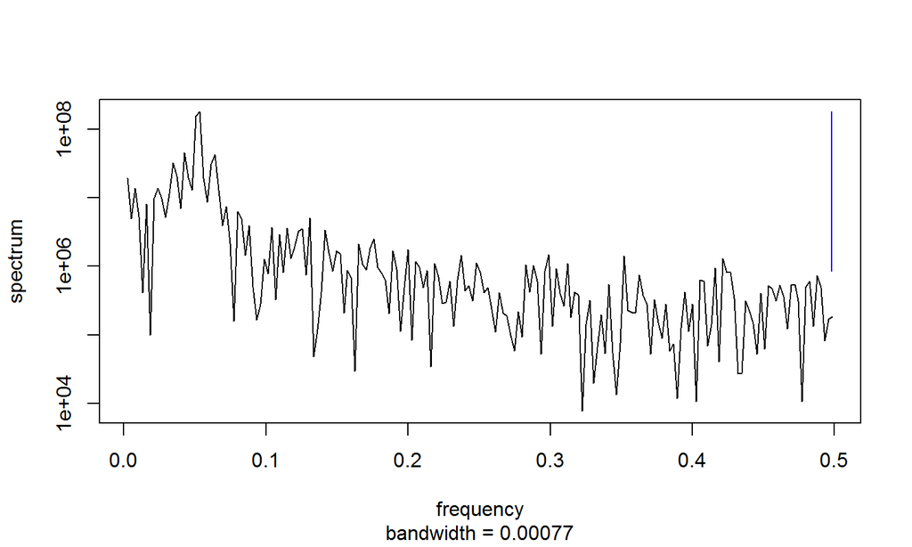

```r
spectrum(flies, main = "")
```

in this analysis we look for frequency peaks. in this case:

```r
spec<-spectrum(flies, main = "")
```

[figure not shown]

```r
spec$spec %>% which.max() -> maxloc # where's the maximal value ?
max.freq <- (spec$freq)[maxloc] # what's the maximal value ?
max.freq
```

```
## [1] 0.05333333
```

now let’s plot and find the exact value in time units

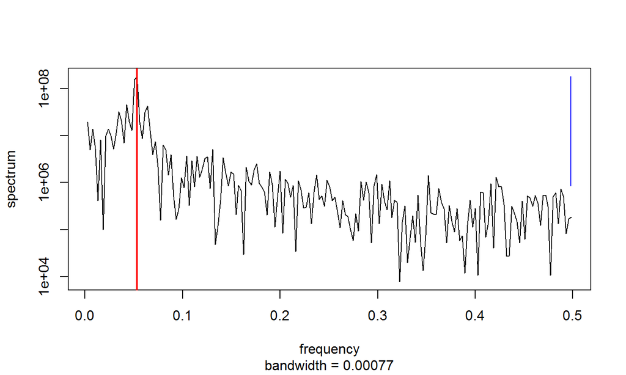

```r
plot(spec, main = "")
abline(v = max.freq, col = "red", lwd = 2)
```

```r
1 / max.freq
```

```
## [1] 18.75
```

suggests again cycles of ~19 years.

the information may or may not be easier to interpret than a correlogram.

it’s best to use both when exploring.

## typical series and interpretations

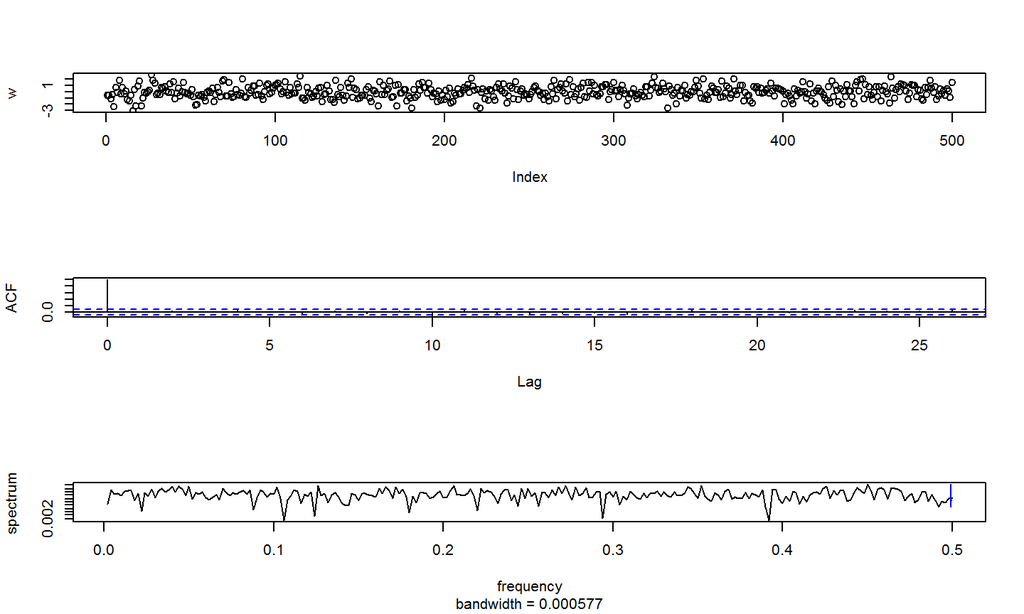

No definitive pattern in lags beyond 0 or a dominant frequency

typical of a *Pure White Noise* process, which is Normal errors around a steady mean.

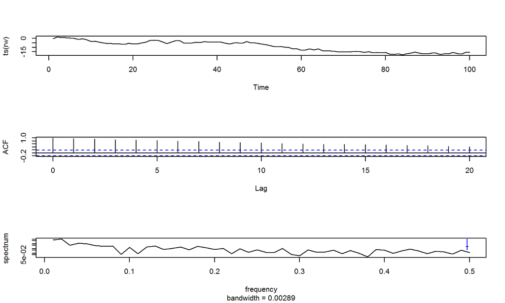

No definitive pattern in lags, but high correlation for all lags

typical of a *Random Walk* process, where values are correlated to (mostly) only the latest value (the values in the previous step), plus a small *white noise*

**Super Important**

Is there a real trend here ? the time plot and our brain say there is. but the underlying process is probably not a *real* trend or combination of trends, but a kind of random ‘drift’.

the next value is more likely to be a minor deviation from the last value, with equal odds for moving up or down, than a result of a another external driver !

random walks are notorious in deceiving our brains. actually, the long term mean of the formula used to create this series, `rw<-cumsum(rnorm(100,0,1))` **is 0 !**

repeat:

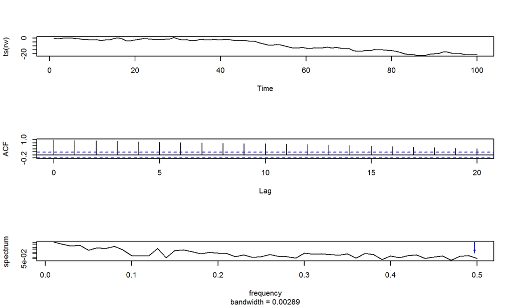

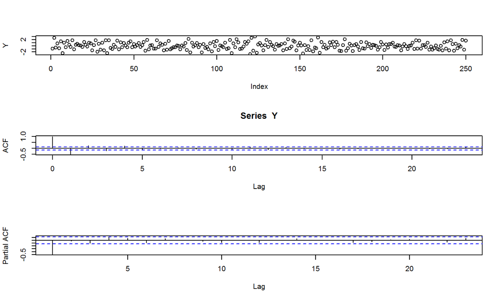

repeated negative followed by positive: return to equilibrium following random departures from it.

This is called an **Autoregressive Process** of order 1 or ‘AR(1)’ (the order can be determined from the `pacf()`) in this case a *negative* AR(1) with rapid response.

ecological models of equilibrium population dynamics are typically Autoregressive.

## analysing parts of a TS + de-trending

Simplest Approach:

1. visually identify a breakpoint
2. apply the same steps on parts of the series to find their attributes and identify discontinuities

now let’s adapt the analysis for the two parts, separately

split the series:

```r
first <- ts(flies[1:200])
second <- ts(flies[201:361])
```

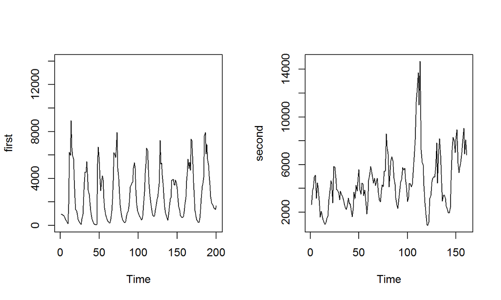

what are the notable differences between the 2 parts ?

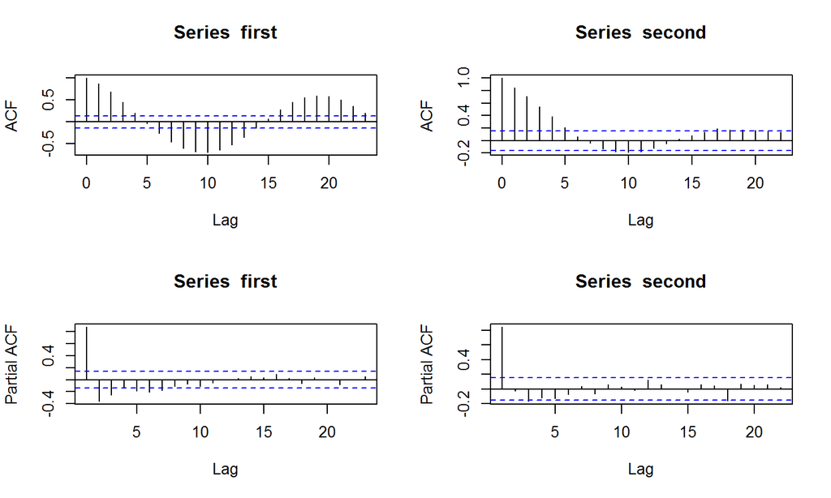

same overall shapes, same cycle length

Important Lags in the *second* parts are shifted 1 or 2, compared with the *first* - change points are somewhat closer to each other

what if we wanted to analyse the two with a commom baseline ?

### de-trending using `lm()`

let’s de-trend using linear regression, and have look at the results.

```r
firstX <- 1:length(first)
first.lm <- lm(first ~ firstX)
first.detrended <- first - predict(first.lm)

secondX <- 1:length(second)
second.lm <- lm(second ~ secondX)
second.detrended <- second - predict(second.lm)
```

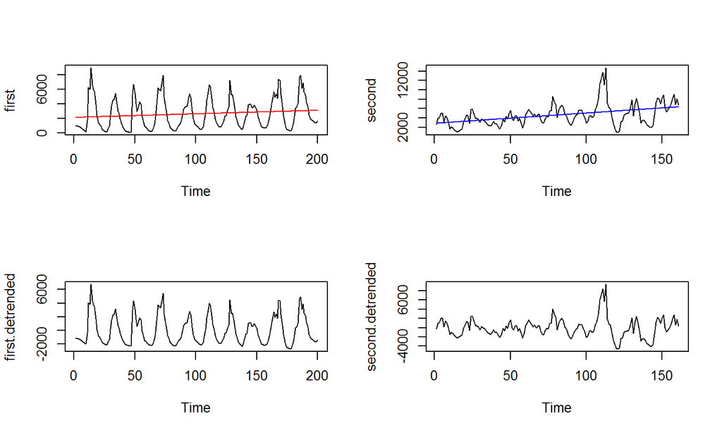

```r
par(mfrow = c(2, 2))
plot(first) ; lines(first.lm$fitted.values, col = "red")
plot(second) ; lines(second.lm$fitted.values, col = "blue")
plot.ts(first.detrended) # reminder Q: why plot.ts ?
plot.ts(second.detrended)
```

```r
par(mfrow = c(1, 1))
```

```r
first.lm$coefficients
```

```
## (Intercept)      firstX
## 2112.433116    4.882556
```

```r
second.lm$coefficients
```

```
## (Intercept)     secondX
##  2827.57461    21.94437
```

now, let’s compare again

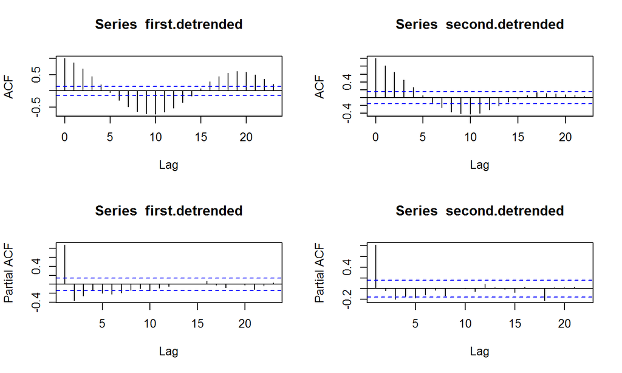

```r
par(mfrow = c(2, 2))
acf(first.detrended) ; acf(second.detrended)
pacf(first.detrended); pacf(second.detrended)
par(mfrow = c(1, 1))
```

comparing the de-trended versions: `acf()` - results similar, but `pacf()` are quite different

conclusions:

- suspected trend change
- continuity in cycle period at the same time as a trend change,
- quite a difference in the underlying change points
- also: a new negative partial coefficient at lag 18

### de-trending using `diff()`

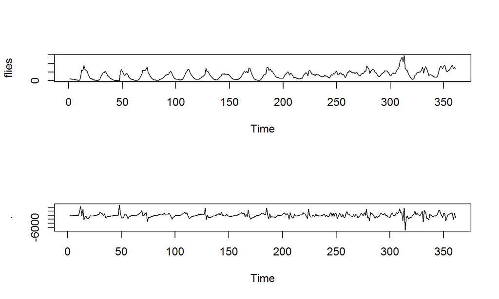

```r
par(mfrow = c(2, 1))
plot(flies)
flies %>% diff() %>% plot()
```

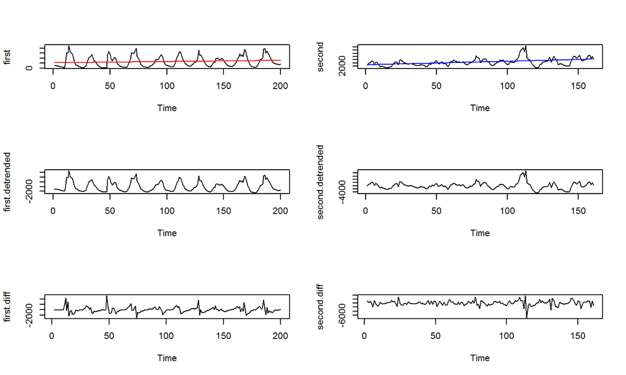

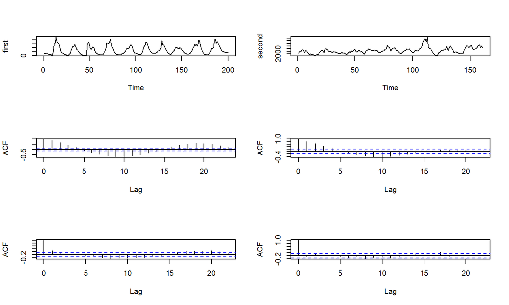

```r
par(mfrow = c(1, 1))
```

### De-trending Remarks

De-trending is the goal of many methods in time series analysis that are not presented here

+first order differencing will usual be enough coerce the series to become stationary, and will do it while still keeping the attributes of the signal. de-trending by a `lm()` may create noise that was not there.

it has several uses in model selection, and the advantage that parameters do not need to be estimated (e.g. from a linear model)

## Smoothing

let’s return to some noisier series

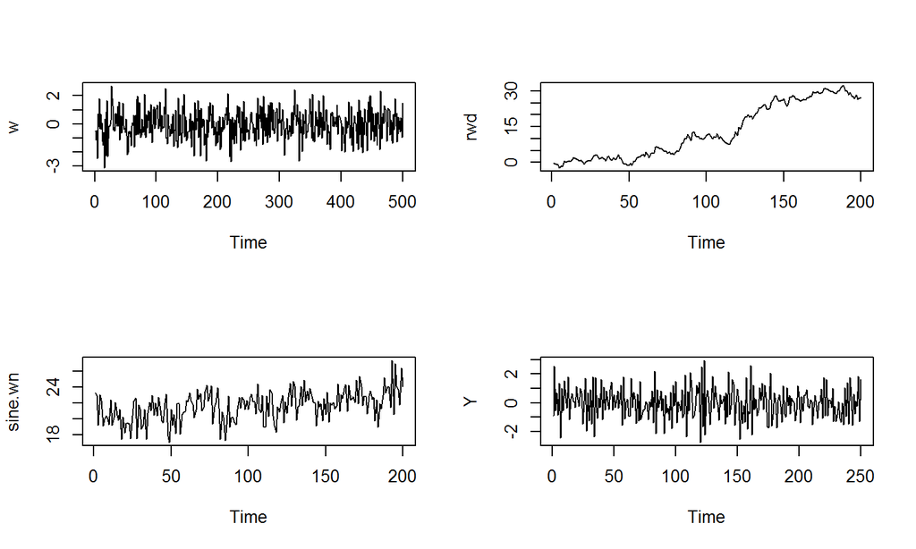

```r
par(mfrow=c(2,2))
plot(w)
plot(rwd)
plot(sine.wn)
plot(Y)
```

```r
par(mfrow=c(1,1))
```

last time we used `window()`

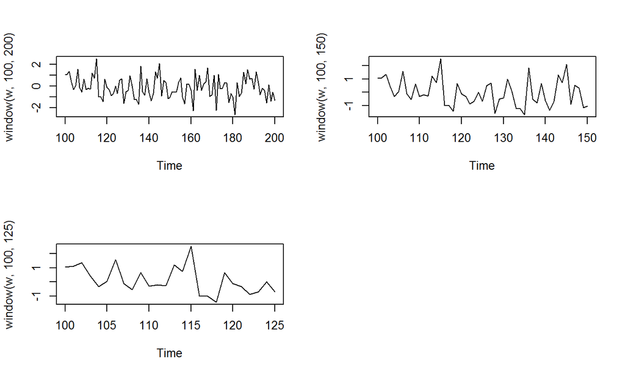

```r
par(mfrow = c(2, 2))

plot(window(w, 100, 200))
plot(window(w, 100, 150))
plot(window(w, 100, 125))

par(mfrow = c(1, 1))
```

this approach doesn’t work

we should probably start looking by smoothing first

### smoothing via `filter()`

`filter` allows many methods for smoothing

#### filtering with a moving average

this is the simplest technique we use the filter argument with a weights vector, giving equal weights

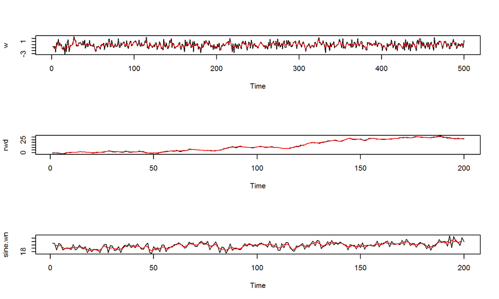

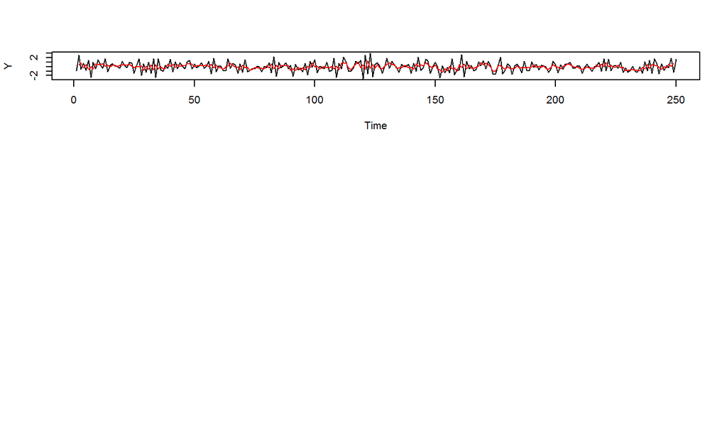

```r
par(mfrow = c(3, 1))

v <- filter(w, sides = 2, filter = rep(1, 3) / 3)
plot(w)
lines(v, col = "red")

rwd.s <- filter(rwd, sides = 2, filter = rep(1, 3) / 3)
plot(rwd)
lines(rwd.s, col = "red")

sine.wn.s <- filter(sine.wn, sides = 2, filter = rep(1, 3) / 3)
plot(sine.wn)
lines(sine.wn.s, col = "red")

Y.s <- filter(Y, sides = 2, filter = rep(1, 3) / 3)
plot(Y)
lines(Y.s, col = "red")

par(mfrow = c(1, 1))
```

let’s try a 9 point average

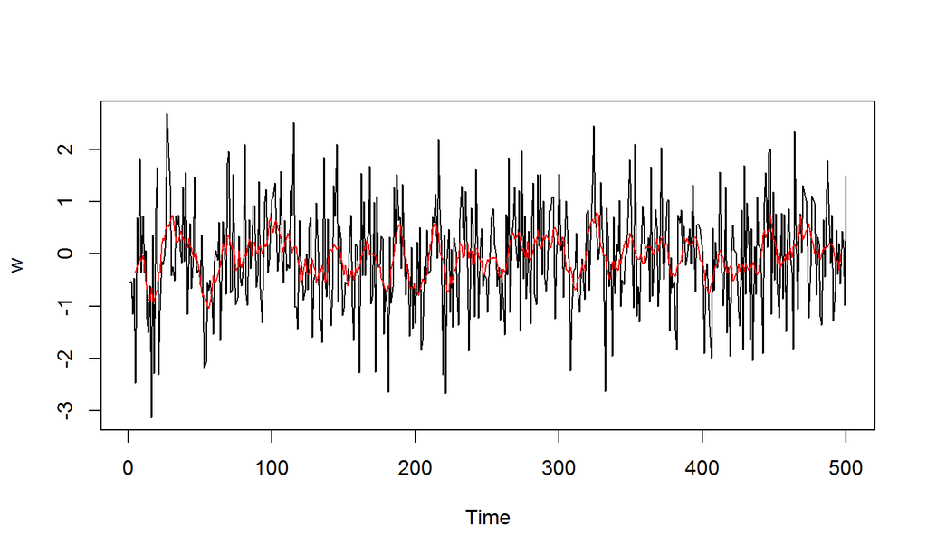

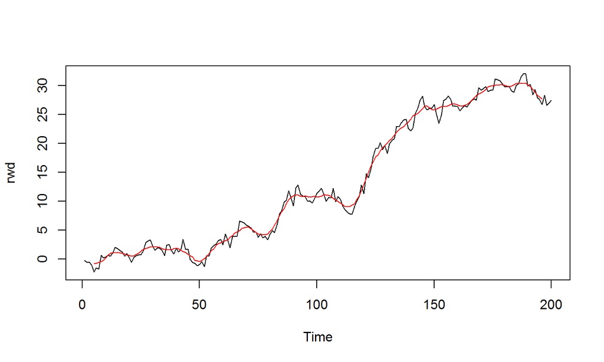

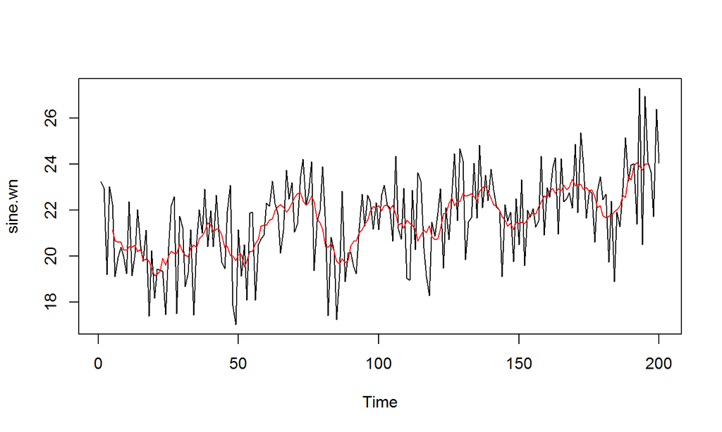

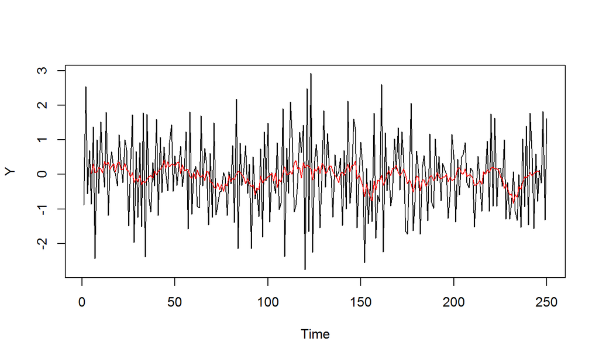

```r
v <- filter(w, sides = 2, filter = rep(1, 9) / 9)
plot(w)
lines(v, col = "red")

rwd.s <- filter(rwd, sides = 2, filter = rep(1, 9) / 9)
plot(rwd)
lines(rwd.s, col = "red")

sine.wn.s <- filter(sine.wn, sides = 2, filter = rep(1, 9) / 9)
plot(sine.wn)
lines(sine.wn.s, col = "red")


Y.s <- filter(Y, sides = 2, filter = rep(1, 9) / 9)
plot(Y)
lines(Y.s, col = "red")
```

let’s try a 15 point average

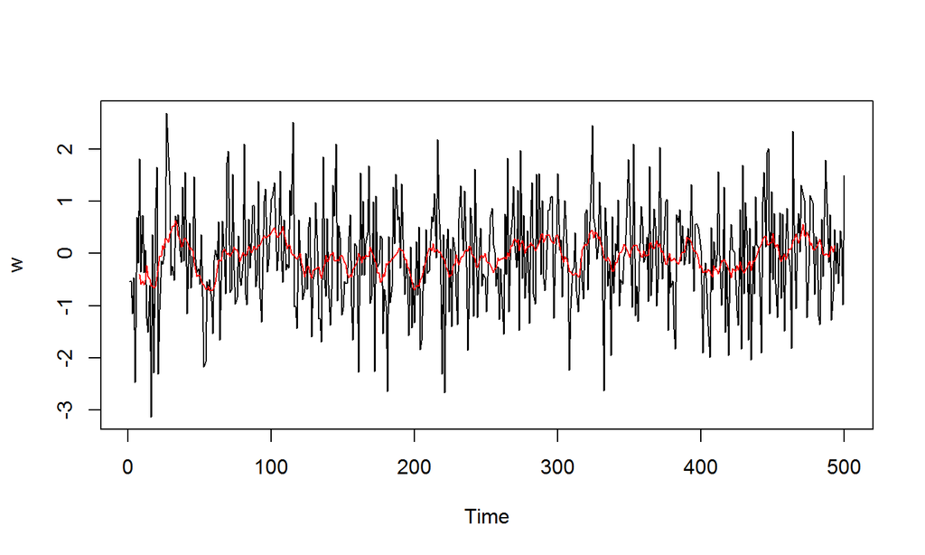

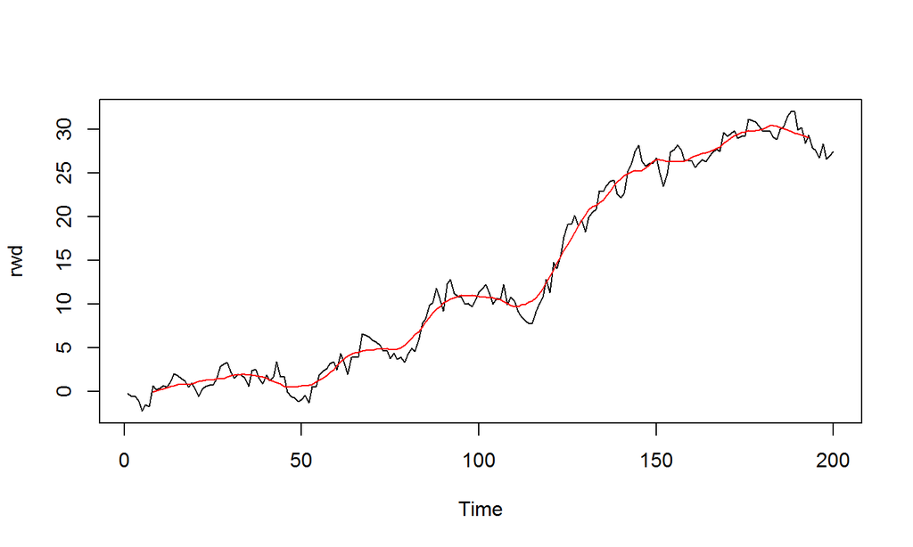

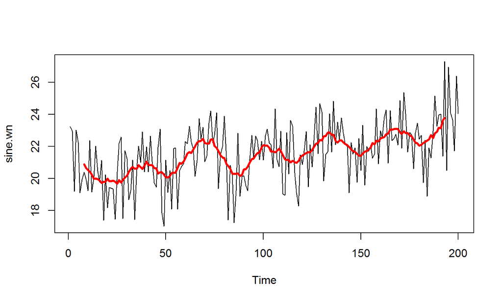

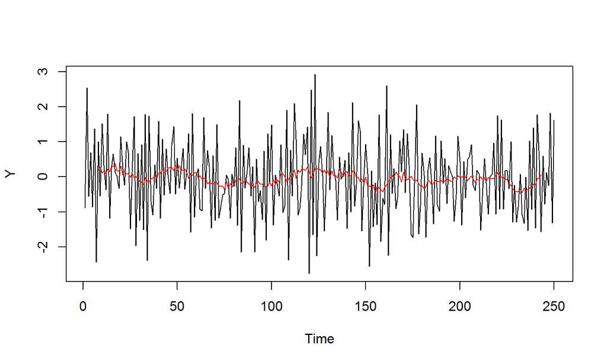

```r
v <- filter(w, sides = 2, filter = rep(1, 15) / 15)
plot(w)
lines(v, col = "red")

rwd.s <- filter(rwd, sides = 2, filter = rep(1, 15) / 15)
plot(rwd)
lines(rwd.s, col = "red")

sine.wn.s <- filter(sine.wn, sides = 2, filter = rep(1, 15) / 15)
plot(sine.wn)
lines(sine.wn.s, col = "red", lwd = 3)


Y.s <- filter(Y, sides = 2, filter = rep(1, 15) / 15)
plot(Y)
lines(Y.s, col = "red")
```

increase the averaging period to receive a smoother results and (maybe) reveal patterns in the noise

a moving average is a *local smoother*, meaning it allows a change of series behaviour through out the series.

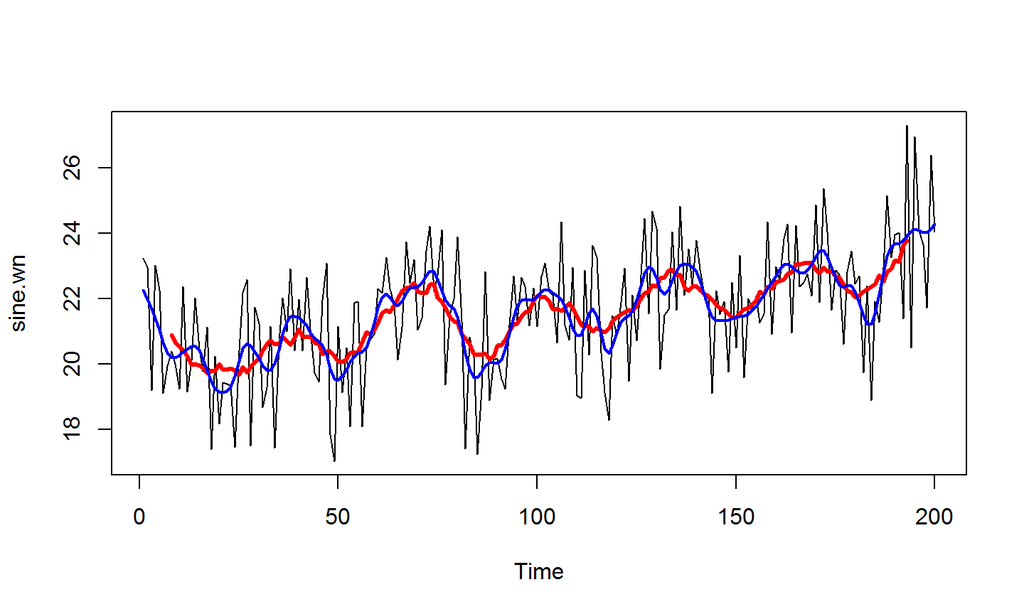

```r
t <- 1:length(sine.wn)

plot(sine.wn)
lines(sine.wn.s, col = "red", lwd = 3)
lines(ksmooth(t, sine.wn, "normal", bandwidth = 5), col = "blue", lwd = 2)
```

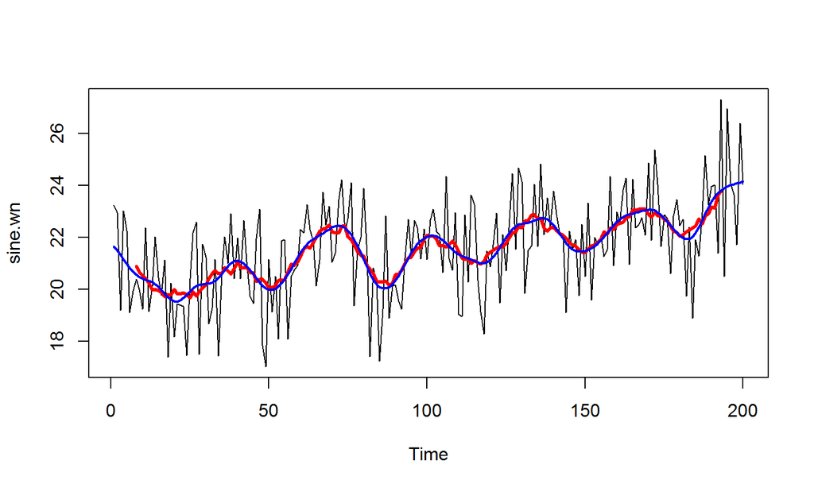

```r
plot(sine.wn)
lines(sine.wn.s, col = "red", lwd = 3)
lines(ksmooth(t, sine.wn, "normal", bandwidth = 10), col = "blue", lwd = 2)
```

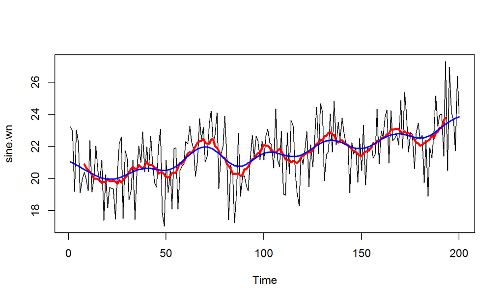

```r
plot(sine.wn)
lines(sine.wn.s, col = "red", lwd = 3)
lines(ksmooth(t, sine.wn, "normal", bandwidth = 20), col = "blue", lwd = 2)
```

The wider the bandwidth, the smoother the result

#### smoothing via `smooth.spline()`

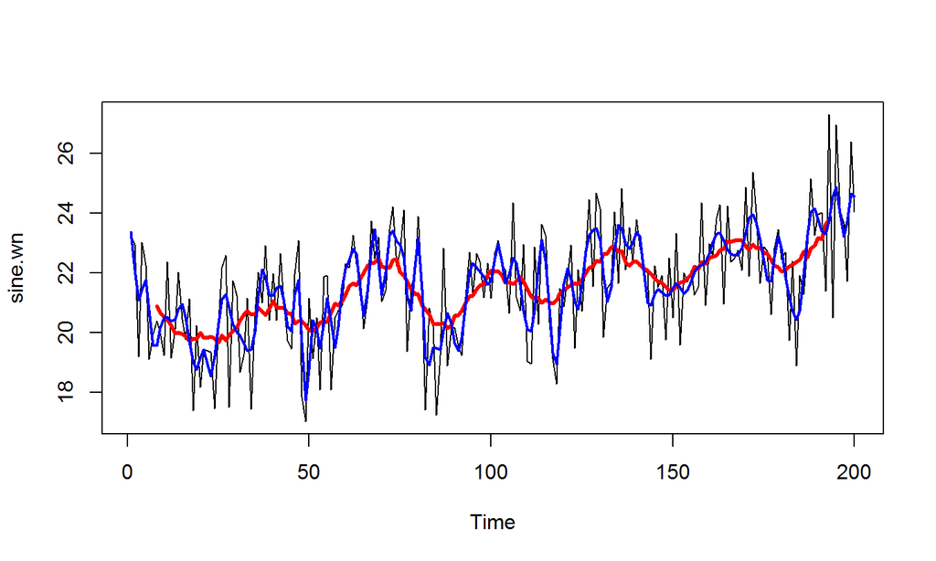

```r
t <- 1:length(sine.wn)

# smoothing paraeter=0.1
plot(sine.wn)
lines(sine.wn.s, col = "red", lwd = 3)
lines(smooth.spline(t, sine.wn, spar = 0.1), col = "blue", lwd = 2)
```

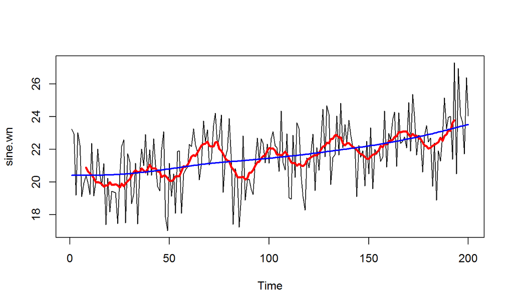

```r
# smoothing paraeter=1
plot(sine.wn)
lines(sine.wn.s, col = "red", lwd = 3)
lines(smooth.spline(t, sine.wn, spar = 1), col = "blue", lwd = 2)
```

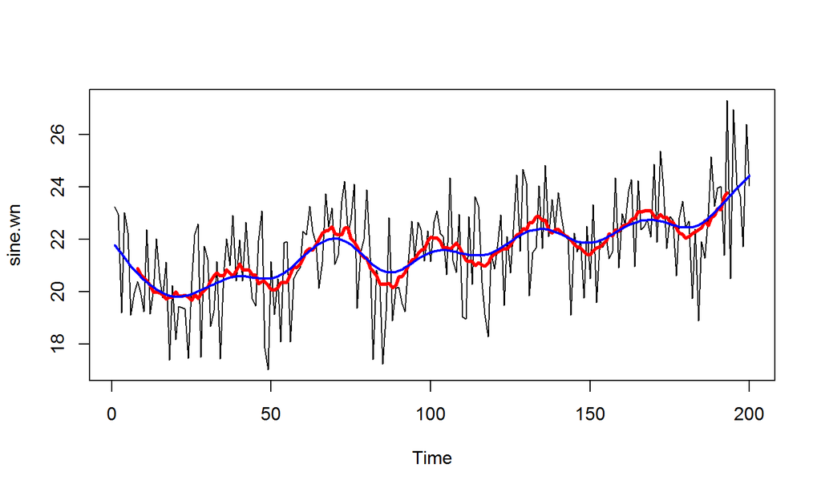

```r
# smoothing paraeter=0.7
plot(sine.wn)
lines(sine.wn.s, col = "red", lwd = 3)
lines(smooth.spline(t, sine.wn, spar = 0.7), col = "blue", lwd = 2)
```

#### smoothing via several methods

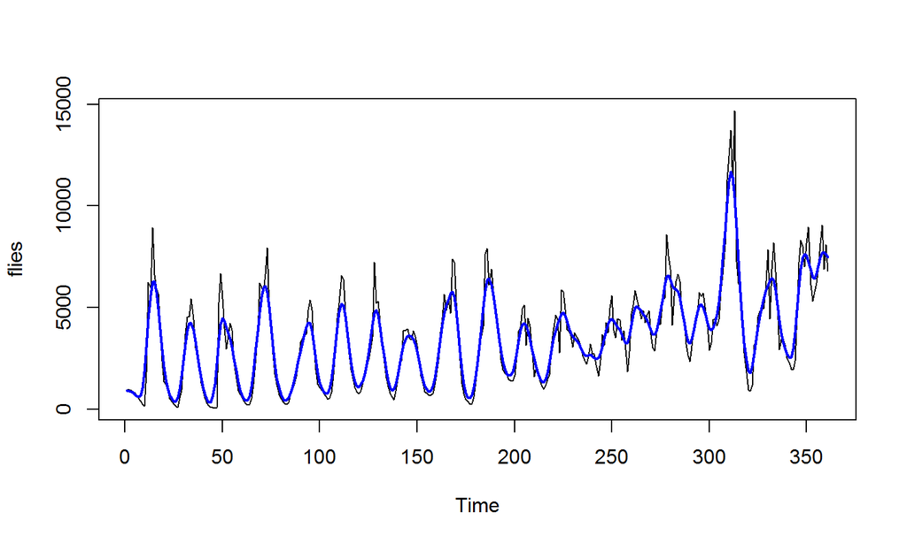

```r
t <- 1:length(flies)

plot(flies)
lines(ksmooth(t, flies, "normal", bandwidth = 5), col = "blue", lwd = 2)
```

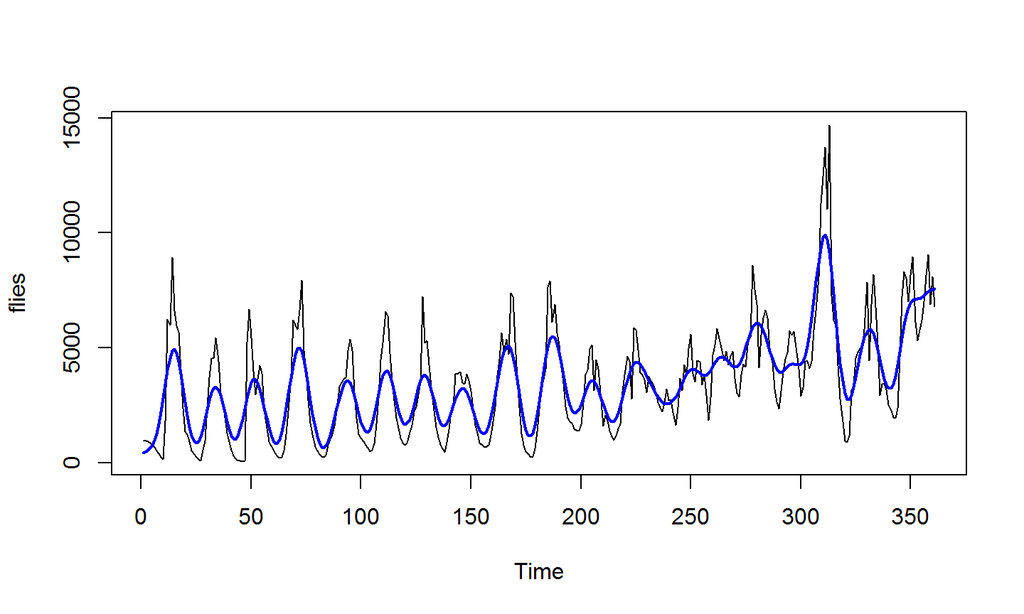

```r
# spline smoothing smoothing paraeter=0.4
plot(flies)
lines(smooth.spline(t, flies, spar = 0.4), col = "blue", lwd = 2)
```

## Conclusion & Remarks

The description of a given time series is usually a cyclical process by itself

some methods that are covered here are also useful in other contexts (e,g. model fitting, control)

## Further Steps

- Model fitting or Comparison
- Forecasting
- Discussion of outliers
- Statistical Theory
- Statistical Methodology

## General Warnings

- many methods, not described here, do have some underlying assumption. most commonly the assumption of *Stationarity*
- Most of the methodology of time series covers **only discrete time and continuous (or pseudo-continuous) variable** (e.g. binary and point process are not covered)
- many of the methods do not describe short and relatively stable series ( like a 10 points richness series) well enough for analysis

## Terminology & Abbreviations

## R functions

| function | Purpose |
| --- | --- |
| ts | construct a time series object |
| ts.plot | plot a vector or matrix as if they were of the special ‘ts’ class. |
| window | have a look at sections of series |
| lag.plot | create a scatter-plot matrix by lags |
| acf , pacf , ccf | study serial correlation |
| Diff | recode the series by differencing |
| lm | construct a Linear Model, such a simple univariate regression to remove a trend |
| filter, ksmooth, smooth.spline | applying linear and non linear filters. in the context of this lesson - for smoothing |

## Process Terminology

*Process* - a mathematical description of observations as a function of time (and perhaps other variables)

*Stationary Process* (intuitive definition, non formal) :

- No systemic change in mean (no trend)
- No systemic change in variance
- Strictly periodic variations have been removed

In other words, The properties of various sections of the data are constant

- Usually in the context of model fitting
- Non Stationarity components (trend, cycles) may be the focus, or we may want to remove them prior to analysis
- much of the probability theory of time series analysis concerns only stationary series, so we may need to transform a given series to stationary

NOTE: No real process is strictly Stationary !

## Series Terminology

| Term | Refers to |
| --- | --- |
| Continuous | Observations are made continuously through time (even if the variable of interest can only take certain) |
| Deterministic | a time series that can be predicted exactly, by a well defined mathematical process |
| Discrete | observations are taken at specific times |
| Equidistant | A series where the variable is recorded at equal intervals (e.g every month) |
| Lag | The time- distance between points in the series, also used for delay lengths in process/series descriptions |
| Stationary | See above |
| Stochastic | The future is only partly determined by the past/ exact predictions are impossible and are replaced by the idea that future values have a probability distribution |

## Process Types Terminology

| Term | Refers to |
| --- | --- |
| Point Process | Binary Observations occur randomly at non equal interval |
| Binary Process | Observations can take only “0” or “1”, Yes/No and so on |

## Abbreviations and Notation

| Term | Refers to |
| --- | --- |
| ACF or ac.f | Autocorrelation Function |
| pACF | Partial (corr. coefficient) ACF |
| AR | Autoregressive |
| MA | Moving Average |

## Source Material and useful links

## Useful Links

CRAN Task View: Time Series Analysis https://cran.r-project.org/web/views/TimeSeries.html

Time Series Modelling basics, explained simply albeit with some theory mistakes https://www.analyticsvidhya.com/blog/2015/12/complete-tutorial-time-series-modelling/

Basic Data Analysis for Time Series with R https://library.books24x7.com/toc.aspx?bookid=63461 (requires a library login + a books 24/7 account)

Looking for real ecological time series ?

- BIOTIME - a Global database of biodiversity time series http://biotime.st-andrews.ac.uk/
- NEON - a repository for LTERs

https://data.neonscience.org/browse-data?showAllDates=true&showAllSites=true&showTheme=org

- DEIMS - another repository for LTERs https://deims.org/

## Bibliography

Heavily based on some Textbooks and R manuals

- Chatfield - Chapters 1, 2 & 6 Chatfield, Christopher. 2004. The Analysis of Time Series: An Introduction. 6th ed. Texts in Statistical Science. Boca Raton, FL: Chapman & Hall/CRC.
- Shumway & Stoffer - Chapters 1, 2 & 4 Shumway, Robert H., and David S. Stoffer. 2006. Time Series Analysis and Its Applications: With R Examples. 2nd [updated] ed. Springer Texts in Statistics. New York: Springer.
- The R book by Crawley - Chapter 24 Crawley, Michael J. 2013. The R Book. Second edition. Chichester, West Sussex, United Kingdom: Wiley.

There are many others…